# PSY4210 Lab Report - 2023 - Part 2

33777594 – Farhanul Majumder

2023-05-18

# Set up

```r
library(haven)
library(data.table)
library(JWileymisc)
library(ggplot2)
library(ggpubr)
library(visreg)

# Add other packages you need here
library(tufte)
library(mice)
library(VIM)
library(lme4)
library(lmerTest)
library(multilevelTools)
library(emmeans)
```

# Loading Data

```r
## read in the dataset
data(aces_daily)
d <- as.data.table(aces_daily)

## between person data, no missing
davg <- na.omit(d[, .(
 Female = factor(na.omit(Female)[1], levels = 0:1),
 Age = na.omit(Age)[1],
 STRESS = mean(STRESS, na.rm = TRUE),
 PosAff = mean(PosAff, na.rm = TRUE),
 NegAff = mean(NegAff, na.rm = TRUE)),
 by = UserID])

## create missing data
davgmiss <- copy(davg)
davgmiss[STRESS < 1, NegAff := NA]
davgmiss[STRESS > 4, PosAff := NA]

## random missingness on age
set.seed(1234)
davgmiss[, Age := ifelse(rbinom(
 .N, size = 1, prob = .1) == 1,
 NA, Age)]

## drop unneeded variables to make analysis easier
davgmiss[, UserID := NULL]
```

# 3. Missing Data

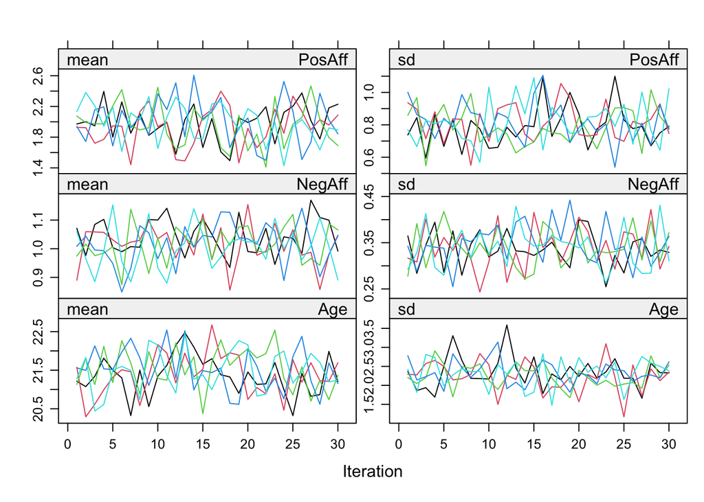

```r
## multiply impute data
mi.1 <- mice(
  davgmiss,
  m = 5,   maxit = 30,
  defaultMethod = c("norm", "logreg", "polyreg", "polr"),
  seed = 1234, printFlag = FALSE)

## convergence plot
plot(mi.1, PosAff + NegAff + Age ~ .it | .ms)
```

```r
## linear regression with imputed dataset
mi.reg <- with(mi.1, lm(STRESS ~ NegAff + Age))

mi.reg #print
```

```
## call :
## with.mids(data = mi.1, expr = lm(STRESS ~ NegAff + Age))
##
## call1 :
## mice(data = davgmiss, m = 5, defaultMethod = c("norm", "logreg",
##     "polyreg", "polr"), maxit = 30, printFlag = FALSE, seed = 1234)
##
## nmis :
## Female    Age STRESS PosAff NegAff
##      0     19      0     30     40
##
## analyses :
## [[1]]
##
## Call:
## lm(formula = STRESS ~ NegAff + Age)
##
## Coefficients:
## (Intercept)       NegAff          Age
##      0.2332       2.2008      -0.0550
##
##
## [[2]]
##
## Call:
## lm(formula = STRESS ~ NegAff + Age)
##
## Coefficients:
## (Intercept)       NegAff          Age
##     0.40385      2.18083     -0.06255
##
##
## [[3]]
##
## Call:
## lm(formula = STRESS ~ NegAff + Age)
##
## Coefficients:
## (Intercept)       NegAff          Age
##    -0.02787      2.17029     -0.04232
##
##
## [[4]]
##
## Call:
## lm(formula = STRESS ~ NegAff + Age)
##
## Coefficients:
## (Intercept)       NegAff          Age
##     0.15774      2.15591     -0.04951
##
##
## [[5]]
##
## Call:
## lm(formula = STRESS ~ NegAff + Age)
##
## Coefficients:
## (Intercept)       NegAff          Age
##    -0.09870      2.16290     -0.03486
```

```r
pool.r.squared(mi.reg) #pooled results with R^2 values
```

```
##          est     lo 95     hi 95      fmi
## R^2 0.608124 0.4939073 0.7035572 0.337145
```

## Missing Data Write up:

The dataset “davgmiss” contained missing data. Multiple imputations were performed to recover the data. 5 imputed datasets were generated, each with 30 iterations. Visually analysing the convergance plot generated revealed that the data was converging. A linear regression with the imputed dataset was performed, with stress as the outcome and negative affect and age as predictors. Results were pooled with an R-Squared value of 0.608, 95% CI = [0.49, 0.70].

# 4. Linear Mixed Models 1

```r
ri.m <- lmer(PosAff ~ 1 + (1 | UserID),
            data = d,
            REML = TRUE)

summary(ri.m)
```

```
## Linear mixed model fit by REML. t-tests use Satterthwaite's method [
## lmerModLmerTest]
## Formula: PosAff ~ 1 + (1 | UserID)
##    Data: d
##
## REML criterion at convergence: 14794.6
##
## Scaled residuals:
##     Min      1Q  Median      3Q     Max
## -4.3450 -0.6468 -0.0341  0.6169  4.0577
##
## Random effects:
##  Groups   Name        Variance Std.Dev.
##  UserID   (Intercept) 0.6289   0.7930
##  Residual             0.5290   0.7273
## Number of obs: 6399, groups:  UserID, 191
##
## Fixed effects:
##              Estimate Std. Error        df t value Pr(>|t|)
## (Intercept)   2.67866    0.05811 189.83088    46.1   <2e-16 ***
## ---
## Signif. codes:  0 '***' 0.001 '**' 0.01 '*' 0.05 '.' 0.1 ' ' 1
```

```r
## calculate intraclass correlation coefficient
iccMixed("PosAff", id = "UserID", data = d)
```

```
##         Var     Sigma       ICC
## 1:   UserID 0.6289046 0.5431472
## 2: Residual 0.5289851 0.4568528
```

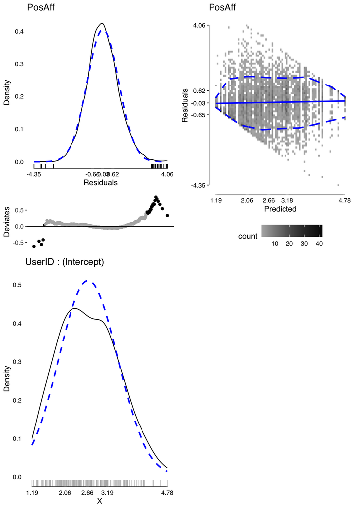

```r
## run model diagnostic
plot(modelDiagnostics(ri.m), ncol = 2, nrow = 2, ask = FALSE)
```

```r
## Confidence interval of the model
confint(ri.m, method = "profile", oldNames = FALSE)
```

```
## Computing profile confidence intervals ...
```

```
##                           2.5 %    97.5 %
## sd_(Intercept)|UserID 0.7157462 0.8795099
## sigma                 0.7147055 0.7402970
## (Intercept)           2.5644941 2.7928351
```

## Linear Mixed Models 1 Write up:

An intercept only linear mixed model was fit to 6399 positive affect scores from 191 people. The intraclass correlation coefficient of positive affect, was 0.5431, indicating that about 54% of the total variance in positive affect was between people and the other 46% was within person due to daily fluctuations. Visual diagnostics showed that positive affect was normally distributed, hence normality assumption appear to be met. Assumptions of homogeneity of variance were met however some extreme values were found (refer to QQ deviates plot). The fixed effect intercept showed that average positive affect was 2.679, 95% CI =[2.56, 2.79]. There were however individual differences in positive affect with standard deviation for random intercept being 0.7930.

# 5. Linear Mixed Models 2

```r
## create a between and within STRESS variable
d[, c("bSTRESS", "wSTRESS") := meanDeviations(STRESS), by = UserID]

## linear mixed model with bSTRESS and wSTRESS predicting NegAff
m1 <- lmer(PosAff ~ bSTRESS + wSTRESS + (1 + wSTRESS | UserID), data = d)

## run model diagnostics
m1.diag <- modelDiagnostics(m1, ev.perc = .005)
```

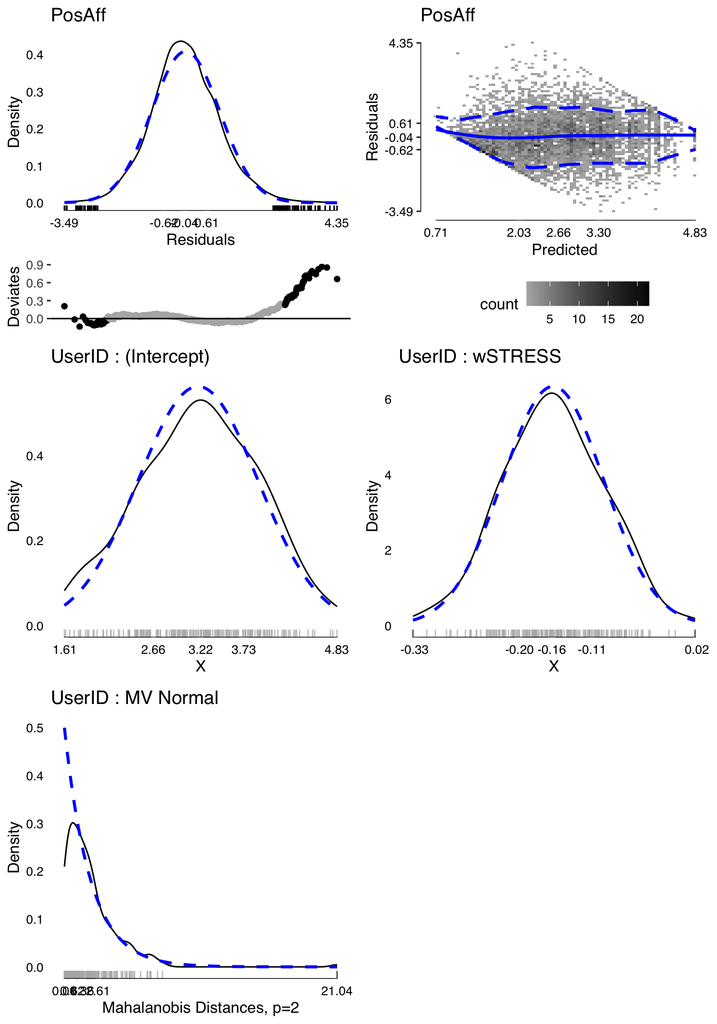

```r
plot(m1.diag, ncol = 2, nrow = 3, ask = FALSE)
```

```r
## identify extreme values
m1.diag$extremeValues
```

```
##        PosAff UserID Index                        EffectType
##   1: 1.456062      7   237                         Residuals
##   2: 1.643745     13   421                         Residuals
##   3: 2.018930     19   643                         Residuals
##   4: 3.052953     21   696                         Residuals
##   5: 4.647537     22   736                         Residuals
##  ---
## 169: 3.446311    123  4237 Multivariate Random Effect UserID
## 170: 2.832955    123  4238 Multivariate Random Effect UserID
## 171: 3.671293    123  4239 Multivariate Random Effect UserID
## 172: 4.893790    123  4240 Multivariate Random Effect UserID
## 173: 4.633870    123  4242 Multivariate Random Effect UserID
```

```r
## creating new dataset with extremevalues removed and rerun model
dnoev <- d[-unique(m1.diag$extremeValues$Index)]
m1noev <- lmer(PosAff ~ bSTRESS + wSTRESS + (1 + wSTRESS | UserID), data = dnoev)
summary(m1noev) #final model summary
```

```
## Linear mixed model fit by REML. t-tests use Satterthwaite's method [
## lmerModLmerTest]
## Formula: PosAff ~ bSTRESS + wSTRESS + (1 + wSTRESS | UserID)
##    Data: dnoev
##
## REML criterion at convergence: 11937.8
##
## Scaled residuals:
##     Min      1Q  Median      3Q     Max
## -2.7908 -0.6515 -0.0389  0.6384  3.3647
##
## Random effects:
##  Groups   Name        Variance Std.Dev. Corr
##  UserID   (Intercept) 0.54198  0.73619
##           wSTRESS     0.00619  0.07868  -0.51
##  Residual             0.34002  0.58311
## Number of obs: 6249, groups:  UserID, 189
##
## Fixed effects:
##               Estimate Std. Error         df t value Pr(>|t|)
## (Intercept)   3.182419   0.095986 200.365793  33.155  < 2e-16 ***
## bSTRESS      -0.224102   0.033813 187.691014  -6.628 3.51e-10 ***
## wSTRESS      -0.159492   0.007134 161.751878 -22.356  < 2e-16 ***
## ---
## Signif. codes:  0 '***' 0.001 '**' 0.01 '*' 0.05 '.' 0.1 ' ' 1
##
## Correlation of Fixed Effects:
##         (Intr) bSTRES
## bSTRESS -0.826
## wSTRESS -0.170 -0.071
```

```r
## confidence interval for new model
m1noev.ci <- confint(m1noev, oldNames = FALSE)
```

```
## Computing profile confidence intervals ...
```

```r
m1noev.ci
```

```
##                                      2.5 %      97.5 %
## sd_(Intercept)|UserID           0.66297553  0.81462567
## cor_wSTRESS.(Intercept)|UserID -0.64849662 -0.35328561
## sd_wSTRESS|UserID               0.06670332  0.09160191
## sigma                           0.57272838  0.59382735
## (Intercept)                     2.99385784  3.37076931
## bSTRESS                        -0.29060888 -0.15768399
## wSTRESS                        -0.17355275 -0.14547678
```

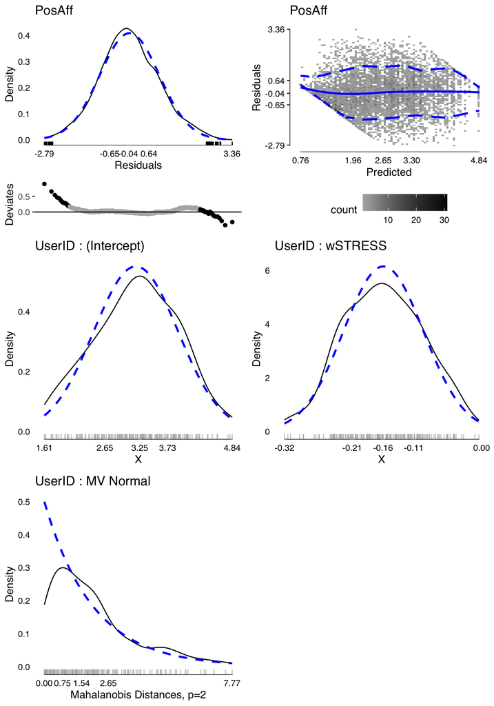

```r
##rerun diagnostics
m1noev.diag <- modelDiagnostics(m1noev, ev.perc = .005)
plot(m1noev.diag, ncol = 2, nrow = 3, ask=FALSE)
```

# 6. Interactions and Moderation for LMMs

```r
## Generate LMM
m2 <- lmer(STRESS ~ SUPPORT + COPEPrb + SUPPORT:COPEPrb + (1 | UserID), data = d)
APAStyler(modelTest(m2),
          pcontrol = list(digits = 3, stars = FALSE, includeP = TRUE,
                          includeSign = TRUE, dropLeadingZero = TRUE))
```

```
## Parameters and CIs are based on REML,
## but modelTests requires ML not REML fit for comparisons,
## and these are used in effect sizes. Refitting.
```

```
##                        Term                          Est           Type
##  1:             (Intercept)  1.96p < .001 [ 1.29,  2.64]  Fixed Effects
##  2:                 COPEPrb  0.74p < .001 [ 0.44,  1.04]  Fixed Effects
##  3:                 SUPPORT -0.13p = .012 [-0.24, -0.03]  Fixed Effects
##  4:         SUPPORT:COPEPrb -0.04p = .122 [-0.08,  0.01]  Fixed Effects
##  5:   sd_(Intercept)|UserID                         1.37 Random Effects
##  6:                   sigma                         2.05 Random Effects
##  7:                Model DF                            6  Overall Model
##  8:              N (Groups)                 UserID (189)  Overall Model
##  9:        N (Observations)                         2090  Overall Model
## 10:                  logLik                     -4627.71  Overall Model
## 11:                     AIC                      9267.42  Overall Model
## 12:                     BIC                      9301.29  Overall Model
## 13:             Marginal R2                         0.07  Overall Model
## 14:             Marginal F2                         0.07  Overall Model
## 15:          Conditional R2                         0.35  Overall Model
## 16:          Conditional F2                         0.55  Overall Model
## 17:         SUPPORT (Fixed)          0.00/0.01, p = .012   Effect Sizes
## 18:         COPEPrb (Fixed)          0.01/0.00, p < .001   Effect Sizes
## 19: SUPPORT:COPEPrb (Fixed)          0.00/0.00, p = .122   Effect Sizes
```

```r
## finding M and SD of COPEPrb to generate simple slope for interaction
egltable(c("COPEPrb"), data = d[!duplicated(UserID)])
```

```
##                 M (SD)
## 1: COPEPrb 2.37 (0.66)
```

```r
## test simple slope
mem <- emtrends(m2, var = "SUPPORT",
                at = list(COPEPrb = c(2.37-0.66, 2.37+0.66)),
                lmer.df = "satterthwaite")
summary(mem, infer = TRUE)
```

```
##  SUPPORT COPEPrb SUPPORT.trend    SE   df lower.CL upper.CL t.ratio p.value
##     5.33    1.71        -0.196 0.023 2045   -0.241   -0.150  -8.501  <.0001
##     5.33    3.03        -0.243 0.031 2086   -0.304   -0.183  -7.844  <.0001
##
## Degrees-of-freedom method: satterthwaite
## Confidence level used: 0.95
```

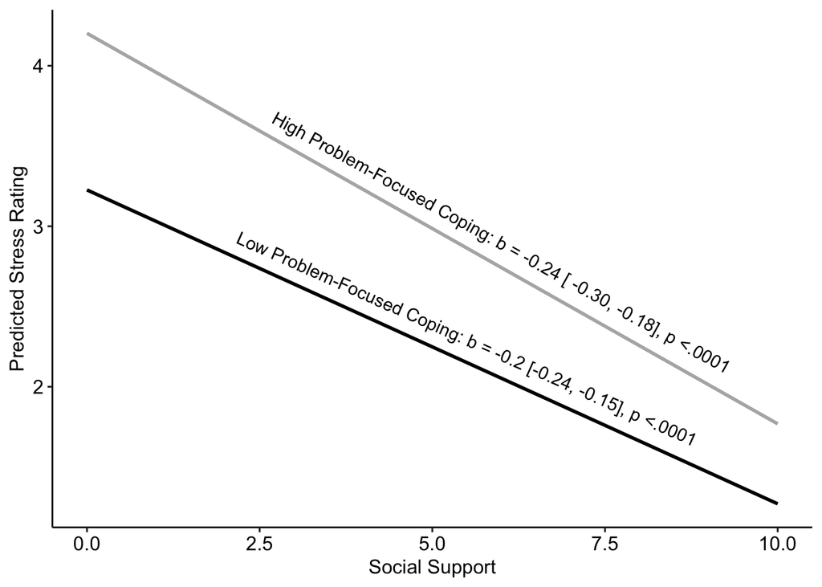

```r
## Create interaction graph
visreg(m2, xvar = "SUPPORT",
       by = "COPEPrb", overlay=TRUE,
       breaks = c(2.37-0.66, 2.37+0.66),
       partial = FALSE, rug = FALSE, gg=TRUE,
       xlab = "Social Support",
       ylab = "Predicted Stress Rating") +
  scale_color_manual(values = c("1.71" = "black", "3.03" = "grey70")) +
  theme_pubr() +
  guides(colour = FALSE, fill = FALSE) +
  annotate(geom = "text", x = 6, y = 2.9,
           label = "High Problem-Focused Coping: b = -0.24 [ -0.30, -0.18], p <.0001",
           angle = -29) +
  annotate(geom = "text", x = 5.5, y = 2.3,
           label = "Low Problem-Focused Coping: b = -0.2 [-0.24, -0.15], p <.0001",
           angle = -24)
```

## Interaction and Moderation for LMMs Write up:

A linear mixed model using restricted maximum likelihood was used to test whether the association of social support on daily stress rating is moderated by problem-focused coping scores. All predictors were included as fixed effects and a random intercept by participant was included.

The social support x problem-focused coping interaction was not statistically significant (-0.04,[95% CI = -0.08, 0.01], p = .122) , which indicated that the relationship between social support and stress did not vary by problem-focused coping. If the interaction was significant, a simple slope analysis could reveal that social support would lead to a decrease in stress at both high and low problem-focused coping.